# *Peakfit* Installation Guide for JPR manuscript

Christoph Stingl, v210428 (#16)

## Installation of *Peakfit* to run as *Skyline* extrenal tools

- install R ([download](https://cran.r-project.org/bin/windows/)) and following packages:

```
install.packages("tidyverse", dependencies = TRUE)
install.packages("minpack.lm", dependencies = TRUE)
install.packages("broom", dependencies = TRUE)
install.packages("purrr", dependencies = TRUE)
```

- download and install *Skyline* and skylinerunner (skylinedaily and skylinedailyrunner) from [MacCoss Lab Software](https://skyline.ms/project/home/software/skyline/begin.view)
- unpack **peakFit.v201130.zip** form supplementary materials into your *Peakfit* folder (e.g. `c:\tools\peakfit`)
- open the command files `run-peakfit.cmd`, `run-peakfit-SIL.cmd`, and `run-peakfit-MS1.cmd` with a text editor (e.g. notepad.exe) and set the location of Rscript.exe:

[figure not shown]

- open `run-peakfit16.R` and set the location of and skylinerunner (or skylinedailyrunner.exe) in line 17.
- between line 20 and 26, default parameters can be specified.

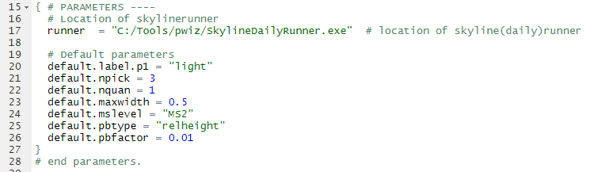

- start *Skyline* (or skylinedaily) and open a blank document.
- Now, add a menu entry for *Peakfit* using *heavy* stable isotope labeled (SIL) peptides to set peak boundaries as external tool by going ‘Tools’ > ‘External tools, then in the External tool window goto ’Add’ > ‘Custom …’ and insert Title (‘Peak Fit SIL’), Command (location of `run-peakfit-SIL.cmd`), Arguments (`$(DocumentPath)`), Initial directory (the directory where *Peakfit* is installed) and activate ‘output to Immediate Window’. Then goto ‘OK’.

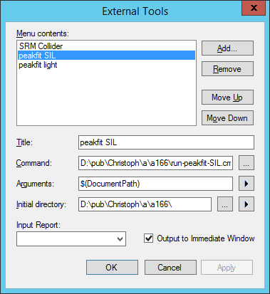

- Repeat the same for *Peakfit* using *light* endogenous peptides to set peak boundaries point the command to `run-peakfit.cmd` and use otherwise the same settings as before:

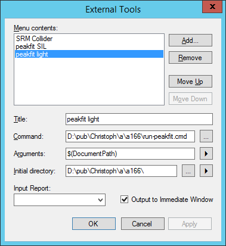

- open the sample data (`a166-ApoE.sky.zip` in data subfolder)
- run *Peakfit* via `Tools` > `peakfit SIL` and wait until the processing is finished

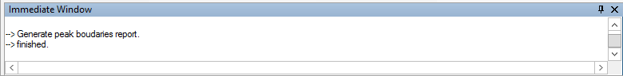

- After completion, results of data processing are stored in `a166-ApoE.peakqc1.txt`
- To check for changes of thepeak picking, import the new peak boundary file (`a166-ApoE.pbrep2.csv`) into *Skyline* (‘File’ > ‘Import’ > ‘Peak boundaries’)

### Data files

- *Skyline* files:
  - **a166-ApoE.sky.zip:** 15 QC samples (global standards) with 10 target peptides (heavy and light)
  - **a166-ApoE-phenotypes.sky.zip:** Samples of if six indivdividual persons, each with one specific Apolipoproteine E phentype (E22, E23, E24, E33, E34, E44)
  - **a166-MS1.sky.zip:** Example processing MS1 precursor data; 26 peptides of 5 selected proteins (CTNNBL1, PUF60, SFB3, DHX15 and HNRNPM) measured in Hela, tryptic digest (Thermo).
  - Results: for each *Skyline* example the processed *Skyline* result (`*--pkft.sky.zip` file), *Peakfit* result table (`*.peakqc1.txt` file) and peak boundaries report (`*.pbrep2.csv`) was added to the result folder.
- Other data files:
  - **210421OFc1_PM38_025.raw.spectrum_table.txt**: “spectrum table” of extract from a RAW file using msaccess.exe ([proteowizard](http://proteowizard.sourceforge.net/) and **210421OFc1_PM38_025.tsv**: tidy version of the spectrum table loadable into R (see information below: Generation tidy spectra table for *basepeakfit*)
  - Result: The result table of the *basepeakfit* run was added to the result folder.

### Generation tidy spectra table for *basepeakfit*

#### 1.) extracting spectrum_table with msaccess.exe (proteowizard)

- Visit http://proteowizard.sourceforge.net/, download proteowizard and install.
- run msconvert on RAW file

```
msconvert.exe 210421OFc1_PM38_025.raw -x "spectrum_table"
```

- A spectrum table file `210421OFc1_PM38_025.raw.spectrum_table.txt` is exported

#### 2.) tidy exported spectrum table file

The exported files needs needs following modifications to be loaded into R:

1.) Remove first line (contains filename), e.g. windows command line command:

```
more +1 210421OFc1_PM38_025.raw.spectrum_table.txt > 210421OFc1_PM38_025.raw.txt
```

2.) Rename hash of column ID (first column) and convert to tab separated values file, e.g. with powershell:

```
$tbl = Get-Content .\210421OFc1_PM38_025.raw.txt
$tbl = $tbl -replace("#", "NULL")
$tbl = $tbl -replace(" {1,}", "`t")
Set-Content .\210421OFc1_PM38_025.tsv $tbl
```

The exported file `210421OFc1_PM38_025.tsv` can be used as input file basepeakfit.R